# Principle Components

Tarek El-Hajjaoui

2023-05-04

## ISLR v2 Chapter 6: Problem 9 - College Applications

```r
library(caret) # createDataPartition
library(leaps) # regsubsets - best subset model
library(glmnet) # glmnet - lasso/ridge regression
library(pls) # pcr, pls
library(dplyr) # arrange
```

```r
file_path = '/Users/Tarek/Documents/UCI_MDS_Coding/Stats211P/R_Statistical_Modeling/ISLRv2_Datasets/College.csv'
df_college <- read.csv(file_path, row.names = NULL, header = TRUE)
df_college <- na.omit(df_college)
# drop column X from the dataframe
df_college$X <- NULL
```

```r
categorical_cols <- c('Private')
df_college[categorical_cols] <- lapply(df_college[categorical_cols], as.factor)
```

```r
str(df_college) # ensure data types correct now
```

```
## 'data.frame':    777 obs. of  18 variables:
##  $ Private    : Factor w/ 2 levels "No","Yes": 2 2 2 2 2 2 2 2 2 2 ...
##  $ Apps       : int  1660 2186 1428 417 193 587 353 1899 1038 582 ...
##  $ Accept     : int  1232 1924 1097 349 146 479 340 1720 839 498 ...
##  $ Enroll     : int  721 512 336 137 55 158 103 489 227 172 ...
##  $ Top10perc  : int  23 16 22 60 16 38 17 37 30 21 ...
##  $ Top25perc  : int  52 29 50 89 44 62 45 68 63 44 ...
##  $ F.Undergrad: int  2885 2683 1036 510 249 678 416 1594 973 799 ...
##  $ P.Undergrad: int  537 1227 99 63 869 41 230 32 306 78 ...
##  $ Outstate   : int  7440 12280 11250 12960 7560 13500 13290 13868 15595 10468 ...
##  $ Room.Board : int  3300 6450 3750 5450 4120 3335 5720 4826 4400 3380 ...
##  $ Books      : int  450 750 400 450 800 500 500 450 300 660 ...
##  $ Personal   : int  2200 1500 1165 875 1500 675 1500 850 500 1800 ...
##  $ PhD        : int  70 29 53 92 76 67 90 89 79 40 ...
##  $ Terminal   : int  78 30 66 97 72 73 93 100 84 41 ...
##  $ S.F.Ratio  : num  18.1 12.2 12.9 7.7 11.9 9.4 11.5 13.7 11.3 11.5 ...
##  $ perc.alumni: int  12 16 30 37 2 11 26 37 23 15 ...
##  $ Expend     : int  7041 10527 8735 19016 10922 9727 8861 11487 11644 8991 ...
##  $ Grad.Rate  : int  60 56 54 59 15 55 63 73 80 52 ...
```

```r
colSums(is.na(df_college)) # count number of nulls in each column
```

```
##     Private        Apps      Accept      Enroll   Top10perc   Top25perc
##           0           0           0           0           0           0
## F.Undergrad P.Undergrad    Outstate  Room.Board       Books    Personal
##           0           0           0           0           0           0
##         PhD    Terminal   S.F.Ratio perc.alumni      Expend   Grad.Rate
##           0           0           0           0           0           0
```

```r
nrow(df_college)
```

```
## [1] 777
```

### 9. a)

Split the data set into a training set and a test set. - Y = Apps, number of applications. - X = All of the other features.

```r
set.seed(0) # set random seed for reproducibility
# split the dataframe into train and test sets
train_indices <- createDataPartition(df_college$Apps, p = 0.7, list = FALSE)
train_college <- df_college[train_indices, ]
train_y <- data.matrix(subset(train_college, select=c('Apps')))
train_X <- data.matrix(train_college[,!names(train_college) %in% c("Apps")])
dim(train_X);dim(train_y) # checking dims of split data
```

```
## [1] 545  17
```

```
## [1] 545   1
```

```r
test_college <- df_college[-train_indices, ]
test_y <- data.matrix(subset(test_college, select=c('Apps')))
test_X <- data.matrix(test_college[,!names(test_college) %in% c("Apps")])
dim(test_X);dim(test_y) # checking dims of split data
```

```
## [1] 232  17
```

```
## [1] 232   1
```

### 9. b)

Fit a linear model using least squares on the training set, and report the test error obtained.

```r
# fit a linear model using least squares on the training set
lr.mod <- lm(Apps ~ ., data = train_college)
# predict the response variable on the test set
lr.pred <- predict(lr.mod, newdata = test_college)
# calculate the test error (mean squared error)
lr.MSE <- mean((lr.pred - test_college$Apps)^2)
lr.MSE
```

```
## [1] 1194439
```

### 9. c)

Fit a ridge regression model on the training set, with $\lambda$ chosen by cross-validation. Report the test error obtained.

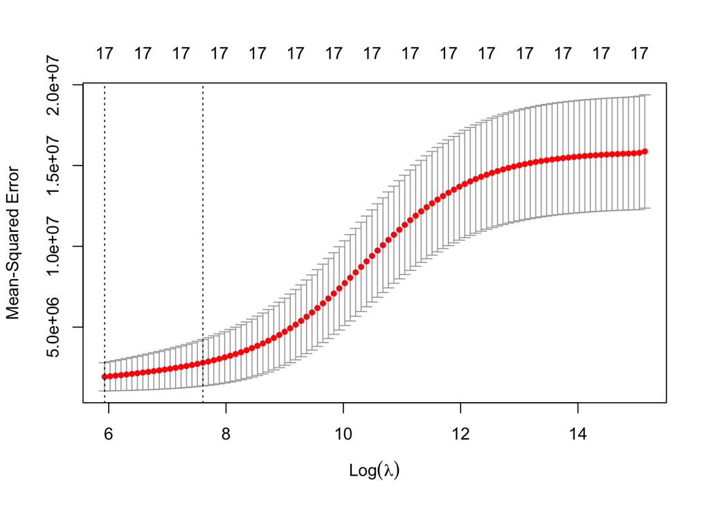

```r
# set up training control object for 10-fold cross-validation
ridge.cv.out <- cv.glmnet(train_X, train_y, alpha = 0)

# plot the hyperparmater tuning cross-validation
plot(ridge.cv.out)
```

```r
# get best lambda
ridge.bestlam <- ridge.cv.out$lambda.min

ridge.mod <- cv.glmnet(train_X, train_y, alpha = 0)

# make predictions with the best lambda
ridge.pred <- predict(ridge.mod, s = ridge.bestlam, newx = test_X)

# calculate test error (mean squared error)
ridge.MSE <- mean((ridge.pred - test_y)^2)

ridge.MSE
```

```
## [1] 1133913
```

### 9. d)

Fit a lasso model on the training set, with $\lambda$ chosen by cross- validation. Report the test error obtained, along with the number of non-zero coefficient estimates.

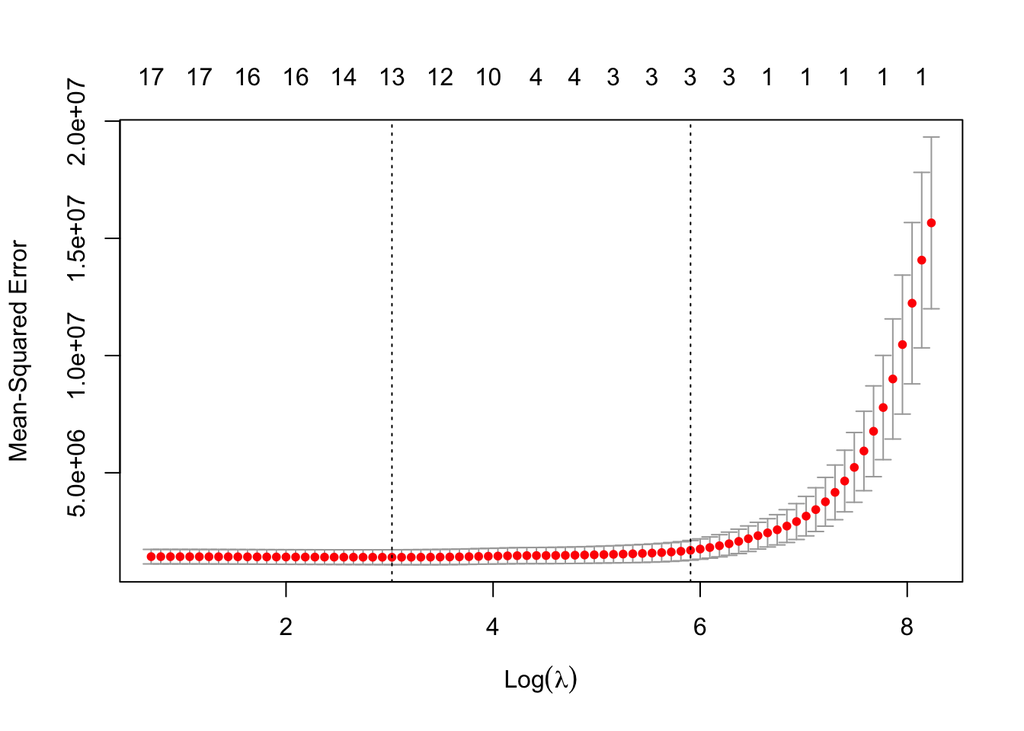

```r
# set up training control object for 10-fold cross-validation
lasso.cv.out <- cv.glmnet(train_X, train_y, alpha = 1)

# plot the hyperparmater tuning cross-validation
plot(lasso.cv.out)
```

```r
# get best lambda
lasso.bestlam <- lasso.cv.out$lambda.min

lasso.mod <- cv.glmnet(train_X, train_y, alpha = 1)

# make predictions with the best lambda
lasso.pred <- predict(lasso.mod, s = lasso.bestlam, newx = test_X)

# calculate test error (mean squared error)
lasso.MSE <- mean((lasso.pred - test_y)^2)

lasso.MSE
```

```
## [1] 1162119
```

### 9. e)

Fit a PCR model on the training set, with M chosen by cross- validation. Report the test error obtained, along with the value of M selected by cross-validation.

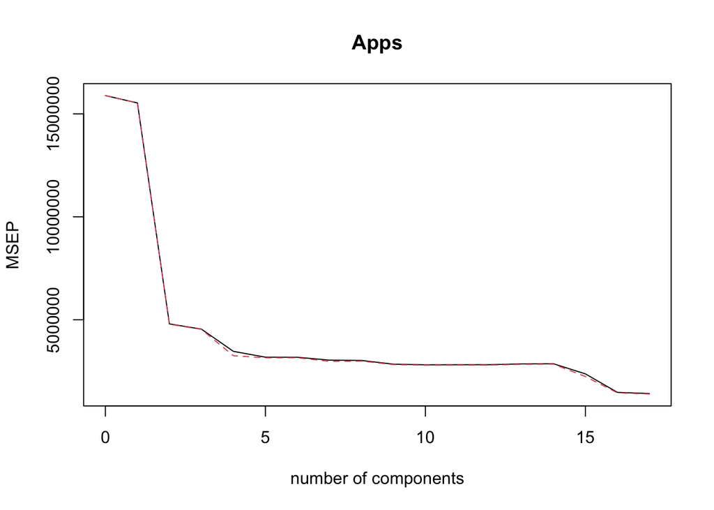

```r
options(scipen=999) # disable scientifit notation

# perform PCR on the training data with CV
pcr.mod <- pcr(Apps ~ ., data = train_college, scale = TRUE,
    validation = "CV") # cross validation

# view CV plot to choose ncomp
validationplot(pcr.mod, val.type = "MSEP")
```

```r
# make predictions
pcr.pred <- predict(pcr.mod, test_college, ncomp = 6)

# calculate test error (mean squared error)
pcr.MSE <- mean((pcr.pred - test_college$Apps)^2)

pcr.MSE
```

```
## [1] 1744790
```

### 9. f)

Fit a PLS model on the training set, with M chosen by cross- validation. Report the test error obtained, along with the value of M selected by cross-validation.

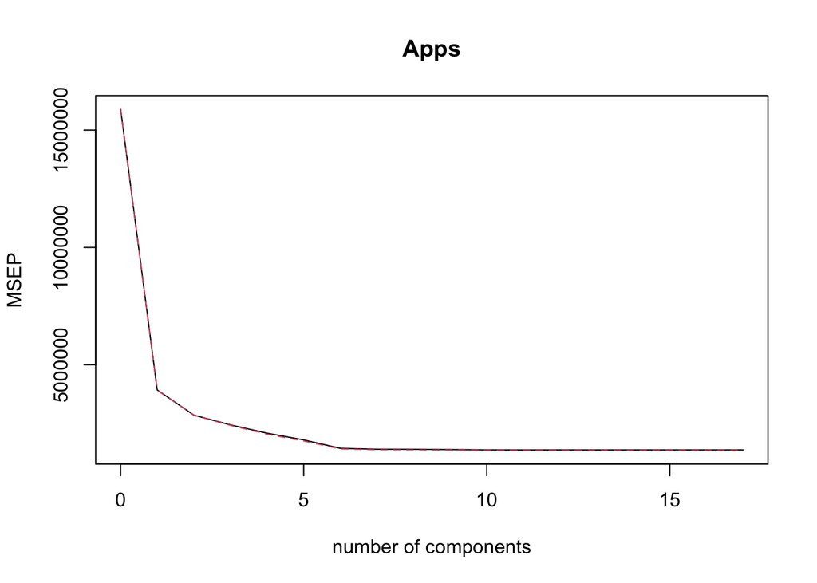

```r
options(scipen=999) # disable scientifit notation

# perform PLS on the training data with CV
pls.mod <- plsr(Apps ~ ., data = train_college, scale = TRUE,
    validation = "CV") # cross validation

# view CV plot to choose ncomp
validationplot(pls.mod, val.type = "MSEP")
```

```r
# make predictions
pls.pred <- predict(pls.mod, test_college, ncomp = 6)

# calculate test error (mean squared error)
pls.MSE <- mean((pls.pred - test_college$Apps)^2)

pls.MSE
```

```
## [1] 1274994
```

### 9. g)

Comment on the results obtained. How accurately can we predict the number of college applications received? Is there much difference among the test errors resulting from these five approaches?

```r
MSE_results <- c(lr.MSE, ridge.MSE, lasso.MSE, pcr.MSE, pls.MSE)
MSE_labels <- c("lr.MSE", "ridge.MSE", "lasso.MSE", "pcr.MSE", "pls.MSE")
df_MSE <- data.frame(Model = MSE_labels, Test_Error = MSE_results)
arrange(df_MSE, desc(Test_Error))
```

```
##       Model Test_Error
## 1   pcr.MSE    1744790
## 2   pls.MSE    1274994
## 3    lr.MSE    1194439
## 4 lasso.MSE    1162119
## 5 ridge.MSE    1133913
```

- With all of the different approaches, there appears to be a high amount of MSE which suggests that we cannot strongly/accurately predict the number of college applications received with the given dataset.
- It is expected for the PCR and PLS models to have higher MSE values than the other models because they are intended to reduce the number of predictor variables. PLS did perform significantly better in terms of MSE which suggests that the dataset has highly correlated predictors or a lot of noise/outliers.
- Ridge regression performs the best in terms of having the lowest MSE, which could be for couple reasons. One possibility is that the true coefficients of some features are small and so lasso elminates them entirely, while ridge regression keeps these coefficients.

## ISLR v2 Chapter 6: Problem 11 - Bostom Crime Rate

```r
file_path = '/Users/Tarek/Documents/UCI_MDS_Coding/Stats211P/R_Statistical_Modeling/ISLRv2_Datasets/Boston.csv'
df_boston <- read.csv(file_path, row.names = NULL, header = TRUE)
df_boston <- na.omit(df_boston)
# drop column X from the dataframe
df_boston$X <- NULL
```

```r
categorical_cols <- c('chas', 'rad')
df_boston[categorical_cols] <- lapply(df_boston[categorical_cols], as.factor)
```

```r
str(df_boston) # ensure data types correct now
```

```
## 'data.frame':    506 obs. of  13 variables:
##  $ crim   : num  0.00632 0.02731 0.02729 0.03237 0.06905 ...
##  $ zn     : num  18 0 0 0 0 0 12.5 12.5 12.5 12.5 ...
##  $ indus  : num  2.31 7.07 7.07 2.18 2.18 2.18 7.87 7.87 7.87 7.87 ...
##  $ chas   : Factor w/ 2 levels "0","1": 1 1 1 1 1 1 1 1 1 1 ...
##  $ nox    : num  0.538 0.469 0.469 0.458 0.458 0.458 0.524 0.524 0.524 0.524 ...
##  $ rm     : num  6.58 6.42 7.18 7 7.15 ...
##  $ age    : num  65.2 78.9 61.1 45.8 54.2 58.7 66.6 96.1 100 85.9 ...
##  $ dis    : num  4.09 4.97 4.97 6.06 6.06 ...
##  $ rad    : Factor w/ 9 levels "1","2","3","4",..: 1 2 2 3 3 3 5 5 5 5 ...
##  $ tax    : int  296 242 242 222 222 222 311 311 311 311 ...
##  $ ptratio: num  15.3 17.8 17.8 18.7 18.7 18.7 15.2 15.2 15.2 15.2 ...
##  $ lstat  : num  4.98 9.14 4.03 2.94 5.33 ...
##  $ medv   : num  24 21.6 34.7 33.4 36.2 28.7 22.9 27.1 16.5 18.9 ...
```

```r
colSums(is.na(df_boston)) # count number of nulls in each column
```

```
##    crim      zn   indus    chas     nox      rm     age     dis     rad     tax
##       0       0       0       0       0       0       0       0       0       0
## ptratio   lstat    medv
##       0       0       0
```

```r
nrow(df_boston)
```

```
## [1] 506
```

### 11. a)

Try out some of the regression methods explored in this chapter, such as best subset selection, the lasso, ridge regression, and PCR. Present and discuss results for the approaches that you consider.

```r
set.seed(0) # set random seed for reproducibility

# split the dataframe into train and test sets
train_indices <- createDataPartition(df_boston$crim, p = 0.7, list = FALSE)
train_boston <- df_boston[train_indices, ]
train_y <- data.matrix(subset(train_boston, select=c('crim')))
train_X <- data.matrix(train_boston[,!names(train_boston) %in% c("crim")])
dim(train_X);dim(train_y) # checking dims of split data
```

```
## [1] 356  12
```

```
## [1] 356   1
```

```r
test_boston <- df_boston[-train_indices, ]
test_y <- data.matrix(subset(test_boston, select=c('crim')))
test_X <- data.matrix(test_boston[,!names(test_boston) %in% c("crim")])
dim(test_X);dim(test_y) # checking dims of split data
```

```
## [1] 150  12
```

```
## [1] 150   1
```

```r
y_true <- test_boston$crim
```

Trying different models: [pcr, best subset, ridge, lasso]

PCR

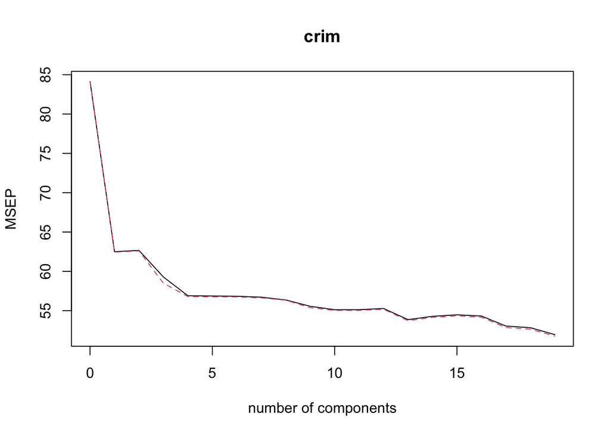

```r
# perform PCR on the training data with CV
pcr.mod <- pcr(crim ~ ., data = train_boston, scale = TRUE,
    validation = "CV") # cross validation
# view CV plot to choose ncomp
validationplot(pcr.mod, val.type = "MSEP")
```

```r
# make predictions
pcr.pred <- predict(pcr.mod, test_boston, ncomp = 5)
# calculate test error (mean squared error)
pcr.MSE <- mean((y_true - pcr.pred)^2)
```

Best Subset

```r
# Best Subset - paramater tuning
k <- 10 # 10-Fold CV
n <- nrow(train_boston)
folds <- sample(rep(1:k, length=n))
cv.errors <- matrix(NA, k, 13, dimnames = list(NULL, paste(1:13)))
test_boston <- na.omit(test_boston)
# perform best subset selection within each of the k training sets
for (j in 1:k) {
  best.fit <- regsubsets(crim ~ .,
                         data = train_boston[folds != j, ],
                         nvmax=13)
  # preparing the test matrix
  test.mat <- model.matrix(crim ~ ., data = train_boston[folds == j, ])
  y_hat <- train_boston$crim[folds == j]
  for (i in 1:13) {
    best.fit.coefi <- coef(best.fit, i)
    # make predictions
    pred <- test.mat[, names(best.fit.coefi)] %*% best.fit.coefi
    # save k-fold mse
    cv.errors[j, i] <- mean((y_hat - pred)^2)
  }
}
# mean for each subset model with i number of features
mean.cv.errors <- apply(cv.errors, 2, mean)
mean.cv.errors
```

```
##        1        2        3        4        5        6        7        8
## 54.30927 53.51607 53.69264 53.30814 52.88034 52.40902 51.99476 52.05052
##        9       10       11       12       13
## 51.94787 51.96967 51.74389 51.58664 51.43240
```

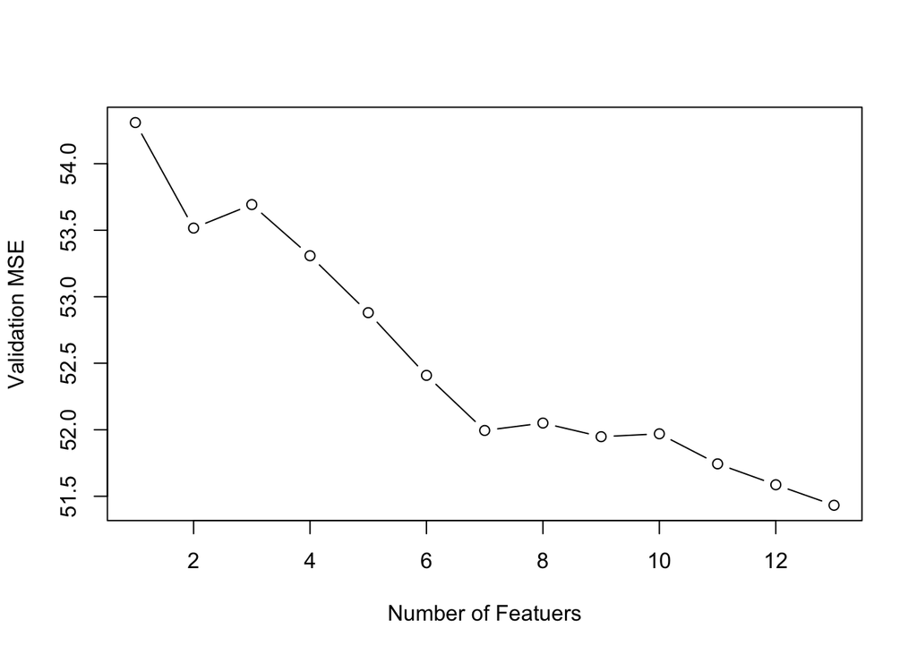

```r
par(mfrow = c(1, 1))
plot(mean.cv.errors, type = "b", xlab = "Number of Featuers", ylab="Validation MSE")
```

```r
# Best Subset - model building with optimal number of features, 13
# fit a best subset model training set
regfit.mod <- regsubsets(crim ~ ., data = train_boston, nvmax = 13)
# preparing the test matrix
test.mat <- model.matrix(crim ~ ., data = test_boston)
regfit.coefi <- coef(regfit.mod, 13)
# predict the response variable on the test set
regfit.pred <- test.mat[, names(regfit.coefi)] %*% regfit.coefi
# calculate the test error (mean squared error)
regfit.MSE <- mean((y_true - regfit.pred)^2)
regfit.MSE
```

```
## [1] 21.89618
```